# Predição de Deputados Eleitos

Valter Lucena

20 de novembro de 2018

```r
library(tidyverse)
library(here)
library(caret)
library(ROSE)
theme_set(theme_minimal())
```

# Introdução

Nesta análise iremos construir modelos de classificação para a predição da eleição dos candidatos à Câmara Federal de Deputados. Anteriormente, [nesta análise](https://rpubs.com/valterlucena/pred-votos), buscamos predizer o total de votos recebidos utilizando técnicas de regressão.

```r
train <- read.csv(here("data/train.csv"))
train %>% names()
```

```
##  [1] "ano"
##  [2] "sequencial_candidato"
##  [3] "nome"
##  [4] "uf"
##  [5] "partido"
##  [6] "quantidade_doacoes"
##  [7] "quantidade_doadores"
##  [8] "total_receita"
##  [9] "media_receita"
## [10] "recursos_de_outros_candidatos.comites"
## [11] "recursos_de_pessoas_fisicas"
## [12] "recursos_de_pessoas_juridicas"
## [13] "recursos_proprios"
## [14] "recursos_de_partido_politico"
## [15] "quantidade_despesas"
## [16] "quantidade_fornecedores"
## [17] "total_despesa"
## [18] "media_despesa"
## [19] "cargo"
## [20] "sexo"
## [21] "grau"
## [22] "estado_civil"
## [23] "ocupacao"
## [24] "situacao"
```

# Perguntas

## Há desbalanceamento das classes (isto é, uma classe tem muito mais instâncias que outra)? Em que proporção? Quais efeitos colaterais o desbalanceamento de classes pode causar no classificador? Como você poderia tratar isso?

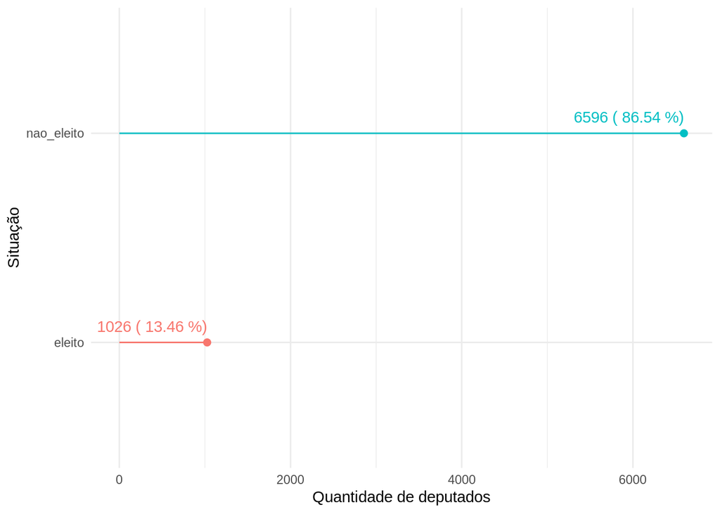

```r
eleitos <- train %>%
  filter(situacao == "eleito") %>%
  count(situacao)

nao_eleitos <- train %>%
  filter(situacao == "nao_eleito") %>%
  count(situacao)

frame = rbind(eleitos, nao_eleitos)

frame %>%
  mutate(proporcao = n / (train %>% nrow())) %>%
  ggplot(aes(x = situacao,
             y = n,
             colour = situacao,
             label = paste(n,"(",round(proporcao * 100, 2),"%)"))) +
  geom_point(size = 2) +
  geom_segment(aes(x = situacao,
                   xend = situacao,
                   y = 0,
                   yend = n)) +
  geom_text(hjust = 1,
            vjust = -1) +
  guides(colour = FALSE) +
  labs(x = "Situação",
       y = "Quantidade de deputados") +
  theme() +
  coord_flip()
```

Como podemos observar no gráfico, existe uma grande diferença entre a quantidade de deputados eleitos e não eleitos na base de dados de treino, ou seja, há sim desbalanceamento entre as classes. Nestes dados, 86.54% são da classe `nao_eleito` e 13.46% são da classe `eleito`. Um efeito desse desbalanceamento é que as predições realizadas utilizando um modelo que foi treinado com esses dados podem ser enviesadas para a classe majoritária. A solução mais comum para este tipo de problema é realizar uma reamostragem nos dados utilizando *undersampling* ou *oversampling*.

- *Undersampling*: são retiradas aleatoriamente amostras da classe majoritária de forma a igualar a quantidade de observações desta com a classe minoritária. Uma desvantagem dessa abordagem é a perda de informação.
- *Oversampling*: as observações da classe minoritária são aleatoriamente duplicadas ou são geradas novas observações para se igualar a quantidade de observações da classe majoritária. Nesta abordagem não há risco de perda de informação, mas aumenta-se o risco de que ocorra um *overfitting*, uma vez que as mesmas amostras podem ser retiradas. Com isto, a capacidade de generalização do modelo seria prejudicada.

## Treine: um modelo de regressão logística, uma árvore de decisão e um modelo de adaboost. Tune esses modelos usando validação cruzada e controle overfitting se necessário, considerando as particularidades de cada modelo.

Vamos, inicialmente, retirar dos dados as variáveis de identificação de um deputado, e as categóricas de apenas um nível.

```r
train <- train %>%
  select(-sequencial_candidato,
         -nome,
         -cargo,
         -uf,
         -ocupacao,
         -partido,
         -estado_civil,
         -grau,
         -ocupacao)
```

Para obtermos uma estimativa honesta do desempenho de cada modelo, utilizaremos ambas as abordagens para desbalanceamento de forma independente a cada fold da validação cruzada.

*Observação*: Os códigos para o treinamento dos modelos estão comentados para que não sejam reexecutados durante a geração do html deste relatório.

### Modelo de Regressão Logística

```r
# reglogControl <- trainControl(method = "repeatedcv",
#                               sampling = "smote",
#                               number = 5,
#                               repeats = 5,
#                               verboseIter = TRUE,
#                               classProbs = TRUE)
#
# regLog <- train(situacao ~ .,
#                 train,
#                 method = "regLogistic",
#                 trControl = reglogControl,
#                 preProcess = c('scale', 'center', 'nzv'))

# saveRDS(regLog, file = "regLog.rds")
regLog <- readRDS(file = "regLog.rds")
regLog
```

```
## Regularized Logistic Regression
##
## 7622 samples
##   15 predictor
##    2 classes: 'eleito', 'nao_eleito'
##
## Pre-processing: scaled (15), centered (15)
## Resampling: Cross-Validated (5 fold, repeated 5 times)
## Summary of sample sizes: 6097, 6098, 6098, 6097, 6098, 6098, ...
## Addtional sampling using SMOTE prior to pre-processing
##
## Resampling results across tuning parameters:
##
##   cost  loss       epsilon  Accuracy   Kappa
##   0.5   L1         0.001    0.9080304  0.6494364
##   0.5   L1         0.010    0.9067178  0.6452874
##   0.5   L1         0.100    0.9065869  0.6392161
##   0.5   L2_dual    0.001    0.9072428  0.6474826
##   0.5   L2_dual    0.010    0.9059046  0.6442057
##   0.5   L2_dual    0.100    0.9075844  0.6470546
##   0.5   L2_primal  0.001    0.9068496  0.6460715
##   0.5   L2_primal  0.010    0.9059567  0.6440351
##   0.5   L2_primal  0.100    0.9088436  0.6457221
##   1.0   L1         0.001    0.9092895  0.6524268
##   1.0   L1         0.010    0.9067707  0.6452842
##   1.0   L1         0.100    0.9084238  0.6431952
##   1.0   L2_dual    0.001    0.9061929  0.6440931
##   1.0   L2_dual    0.010    0.9062719  0.6446972
##   1.0   L2_dual    0.100    0.9064028  0.6449045
##   1.0   L2_primal  0.001    0.9062457  0.6429621
##   1.0   L2_primal  0.010    0.9061405  0.6436491
##   1.0   L2_primal  0.100    0.9091850  0.6476547
##   2.0   L1         0.001    0.9069805  0.6474122
##   2.0   L1         0.010    0.9061144  0.6449711
##   2.0   L1         0.100    0.9082400  0.6428996
##   2.0   L2_dual    0.001    0.9062202  0.6434799
##   2.0   L2_dual    0.010    0.9074001  0.6478712
##   2.0   L2_dual    0.100    0.9066391  0.6467705
##   2.0   L2_primal  0.001    0.9074791  0.6468437
##   2.0   L2_primal  0.010    0.9070593  0.6465582
##   2.0   L2_primal  0.100    0.9089750  0.6459918
##
## Accuracy was used to select the optimal model using the largest value.
## The final values used for the model were cost = 1, loss = L1 and epsilon
##  = 0.001.
```

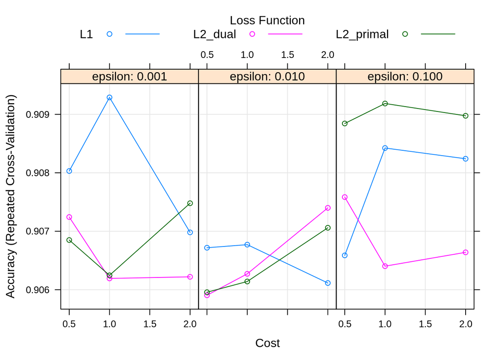

```r
plot(regLog)
```

### Modelo KNN (K-Nearest Neighbours)

```r
# knnGrid <- expand.grid(k = seq(1, 25, length=25))
#
# knnControl <- trainControl(method = "repeatedcv",
#                            sampling = "smote",
#                            number = 5,
#                            repeats = 5,
#                            verboseIter = TRUE,
#                            classProbs = TRUE)
# knn <- train(situacao ~ .,
#              data = train,
#              method = "knn",
#              trControl = knnControl,
#              preProcess = c('scale', 'center', 'nzv'),
#              tuneGrid = knnGrid)
#
# saveRDS(knn, file = 'knnModel.rds')
knn <- readRDS(file = 'knnModel.rds')
knn
```

```
## k-Nearest Neighbors
##
## 7622 samples
##   15 predictor
##    2 classes: 'eleito', 'nao_eleito'
##
## Pre-processing: scaled (15), centered (15)
## Resampling: Cross-Validated (5 fold, repeated 5 times)
## Summary of sample sizes: 6097, 6098, 6098, 6097, 6098, 6098, ...
## Addtional sampling using SMOTE prior to pre-processing
##
## Resampling results across tuning parameters:
##
##   k   Accuracy   Kappa
##    1  0.8791927  0.5630882
##    2  0.8797694  0.5682332
##    3  0.8824457  0.5871799
##    4  0.8809244  0.5831803
##    5  0.8853327  0.6037881
##    6  0.8843874  0.6027220
##    7  0.8848599  0.6064239
##    8  0.8865131  0.6128691
##    9  0.8854899  0.6118642
##   10  0.8862766  0.6140935
##   11  0.8869854  0.6180154
##   12  0.8860666  0.6157830
##   13  0.8862242  0.6181786
##   14  0.8872741  0.6207073
##   15  0.8858832  0.6181954
##   16  0.8861194  0.6174199
##   17  0.8859094  0.6174503
##   18  0.8859616  0.6190964
##   19  0.8873266  0.6223299
##   20  0.8868543  0.6220977
##   21  0.8868802  0.6216215
##   22  0.8871693  0.6221404
##   23  0.8864868  0.6208397
##   24  0.8858305  0.6194665
##   25  0.8873791  0.6240014
##
## Accuracy was used to select the optimal model using the largest value.
## The final value used for the model was k = 25.
```

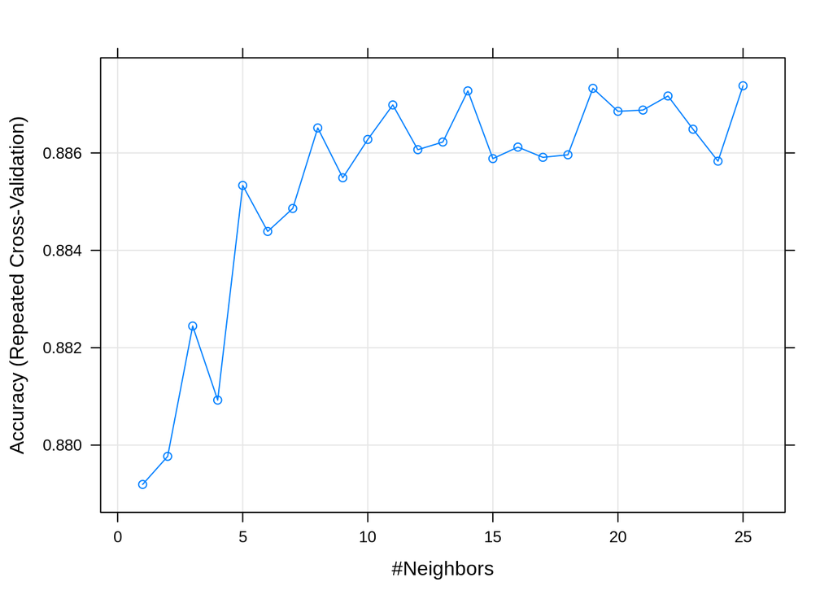

```r
plot(knn)
```

### Árvore de Decisão

```r
# arvore decisao
# dtControl <- trainControl(method = "repeatedcv",
#                           number = 5,
#                           repeats = 5,
#                           sampling = "smote",
#                           verboseIter = TRUE,
#                           classProbs = TRUE)
#
# dtree <- train(situacao ~ .,
#                data = train,
#                method = "rpart",
#                trControl = dtControl,
#                preProcess = c('scale', 'center', 'nzv'),
#                cp = 0.001)
#
# saveRDS(dtree, 'dtree.rds')
dtree <- readRDS(file = "dtree.rds")
dtree
```

```
## CART
##
## 7622 samples
##   15 predictor
##    2 classes: 'eleito', 'nao_eleito'
##
## Pre-processing: scaled (15), centered (15)
## Resampling: Cross-Validated (5 fold, repeated 5 times)
## Summary of sample sizes: 6098, 6096, 6098, 6098, 6098, 6098, ...
## Addtional sampling using SMOTE prior to pre-processing
##
## Resampling results across tuning parameters:
##
##   cp          Accuracy   Kappa
##   0.02631579  0.8697459  0.5919826
##   0.04434698  0.8697459  0.5919826
##   0.26315789  0.8697459  0.5919826
##
## Accuracy was used to select the optimal model using the largest value.
## The final value used for the model was cp = 0.2631579.
```

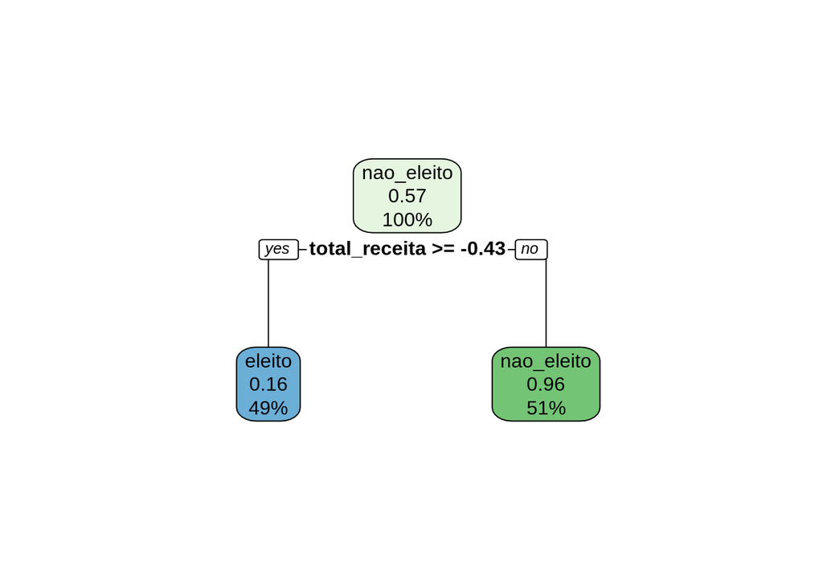

```r
library(rpart.plot)
rpart.plot(dtree$finalModel)
```

### Adaboost

```r
# adaboost
# adaGrid <- expand.grid(nIter = seq(1, 25, length = 25),
#                        method = c("Adaboost.M1", "Real adaboost"))
#
# adaControl <- trainControl(method = "repeatedcv",
#                            sampling = "smote",
#                            number = 5,
#                            repeats = 5,
#                            verboseIter = TRUE,
#                            classProbs = TRUE)
#
# adaboost <- train(situacao ~ .,
#                   train,
#                   method = "adaboost",
#                   trControl = adaControl,
#                   preProcess = c("scale", "center", "nzv"),
#                   tuneGrid = adaGrid)
#
# saveRDS(adaboost, file = "adaboost.rds")
adaboost <- readRDS(file = "adaboost.rds")
adaboost
```

```
## AdaBoost Classification Trees
##
## 7622 samples
##   15 predictor
##    2 classes: 'eleito', 'nao_eleito'
##
## Pre-processing: scaled (15), centered (15)
## Resampling: Cross-Validated (5 fold, repeated 5 times)
## Summary of sample sizes: 6098, 6098, 6098, 6097, 6097, 6097, ...
## Addtional sampling using SMOTE prior to pre-processing
##
## Resampling results across tuning parameters:
##
##   nIter  method         Accuracy   Kappa
##    1     Adaboost.M1    0.8821827  0.5837685
```

[output cut: 53 more lines]

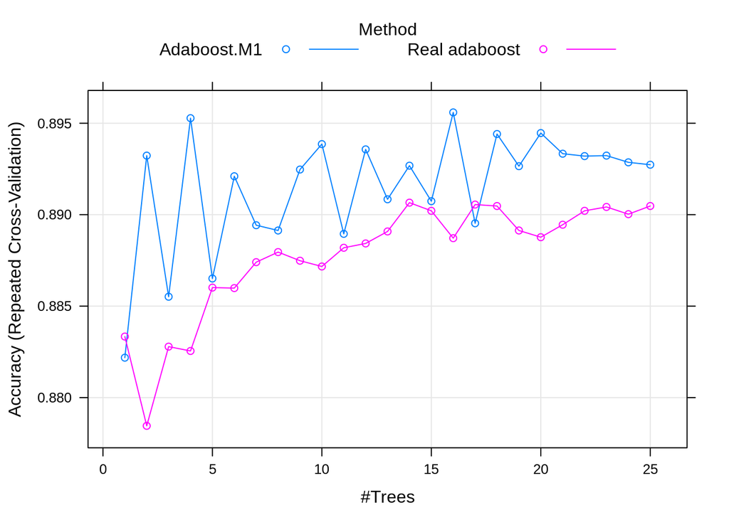

```r
plot(adaboost)
```

## Reporte precision, recall e f-measure no treino e validação. Há uma grande diferença de desempenho no treino/validação? Como você avalia os resultados? Justifique sua resposta.

Todas essas medidas são calculadas em termos de Verdadeiros Positivos (TP), Verdadeiros Negativos (TN), Falsos Positivos (FP) e Falsos Negativos (FN), ou seja, na quantidade de observações onde um candidato previsto como eleito ou não eleito realmente se elegeu ou não se elegeu. Cada medida representa o seguinte:

- Precision: razão entre observações previstas como positivas corretamente (TP) e o total de observações previstas como positivas (TP + FP)

```r
precision <- function(TP, FP) {
  result <- TP / (TP + FP)
  return(result)
}
```

- Recall: proporção de observações previstas como positivas corretamente (TP) entre todas as observações da classe atual (TP + FN)

```r
recall <- function(TP,FN) {
  result <- TP / (TP + FN)
  return(result)
}
```

- F-measure: média ponderada entre *precision* e *recall*. Leva em consideração tanto os falso positivos como os falsos negativos

```r
fmeasure <- function(precision, recall) {
  result <- 2 * (precision * recall) / (precision + recall)
}
```

Pra o modelo de Regressão Logística, temos:

```r
matriz.regLog <- confusionMatrix(regLog)
regLog.precision <- precision(matriz.regLog$table[1], matriz.regLog$table[3])
regLog.recall <- recall(matriz.regLog$table[1], matriz.regLog$table[2])
regLog.fmeasure <- fmeasure(regLog.precision, regLog.recall)

regLog.precision
```

```
## [1] 0.6270697
```

```r
regLog.recall
```

```
## [1] 0.8046784
```

```r
regLog.fmeasure
```

```
## [1] 0.7048579
```

Pra o modelo KNN, temos:

```r
matriz.knn <- confusionMatrix(knn)
knn.precision <- precision(matriz.knn$table[1], matriz.knn$table[3])
knn.recall <- recall(matriz.knn$table[1], matriz.knn$table[2])
knn.fmeasure <- fmeasure(knn.precision, knn.recall)

knn.precision
```

```
## [1] 0.5488459
```

```r
knn.recall
```

```
## [1] 0.9177388
```

```r
knn.fmeasure
```

```
## [1] 0.6868982
```

Pra a árvore de decisão, temos:

```r
matriz.dtree <- confusionMatrix(dtree)
dtree.precision <- precision(matriz.dtree$table[1], matriz.dtree$table[3])
dtree.recall <- recall(matriz.dtree$table[1], matriz.dtree$table[2])
dtree.fmeasure <- fmeasure(dtree.precision, dtree.recall)

dtree.precision
```

```
## [1] 0.5086297
```

```r
dtree.recall
```

```
## [1] 0.9536062
```

```r
dtree.fmeasure
```

```
## [1] 0.663412
```

Para o modelo de Adaboost, temos:

```r
matriz.adaboost <- confusionMatrix(adaboost)
adaboost.precision <- precision(matriz.adaboost$table[1], matriz.adaboost$table[3])
adaboost.recall <- recall(matriz.adaboost$table[1], matriz.adaboost$table[2])
adaboost.fmeasure <- fmeasure(adaboost.precision, adaboost.recall)

adaboost.precision
```

```
## [1] 0.578588
```

```r
adaboost.recall
```

```
## [1] 0.8259259
```

```r
adaboost.fmeasure
```

```
## [1] 0.6804786
```

## Interprete as saídas dos modelos. Quais atributos parecem ser mais importantes de acordo com cada modelo?

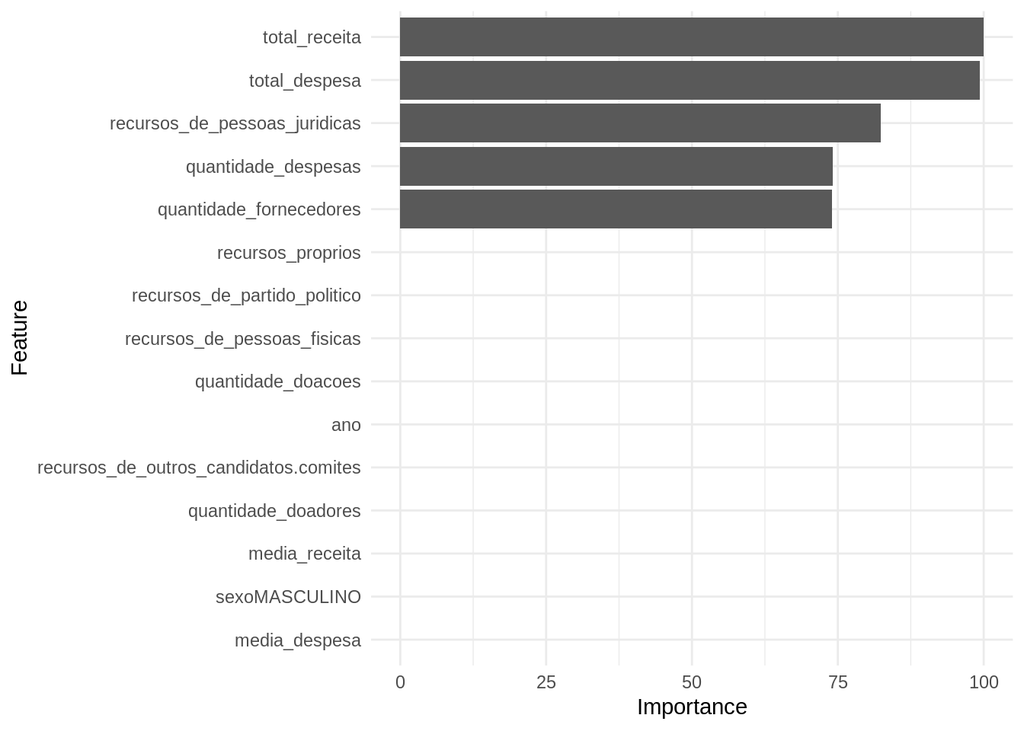

```r
ggplot(varImp(dtree))
```

Para a árvore de decisão, as variáveis mais importantes foram `total_receita`, `total_despesa`, `recursos_de_pessoas_juridicas`, `quantidade_despesas` e `quantidade_fornecedores`.

## Envie seus melhores modelos à competição do Kaggle. Faça pelo menos uma submissão. Sugestões para melhorar o modelo:

```r
# best.model.grid <- expand.grid(adaboost$bestTune)
# best.model <- train(situacao ~ .,
#                     train,
#                     method = "adaboost",
#                     trControl = trainControl(verboseIter = TRUE),
#                     tuneGrid = best.model.grid)
# saveRDS(best.model, file="bestModel.rds")
best.model <- readRDS(file="bestModel.rds")
best.model
```

```
## AdaBoost Classification Trees
##
## 7622 samples
##   15 predictor
##    2 classes: 'eleito', 'nao_eleito'
##
## No pre-processing
## Resampling: Bootstrapped (25 reps)
## Summary of sample sizes: 7622, 7622, 7622, 7622, 7622, 7622, ...
## Resampling results:
##
##   Accuracy  Kappa
##   0.904791  0.5785824
##
## Tuning parameter 'nIter' was held constant at a value of 16
##
## Tuning parameter 'method' was held constant at a value of Adaboost.M1
```

Primeiramente vamos aplicar todas as modificações do modelo de treino no modelo de teste.

```r
test <- read.csv(here("data/test.csv"))
submission <- test %>% select(sequencial_candidato)
test <- test %>%
  select(-sequencial_candidato,
         -nome,
         -cargo,
         -uf,
         -ocupacao,
         -partido,
         -estado_civil,
         -grau,
         -ocupacao)
predictions <- predict(best.model, test)
submission$situacao <- predictions
submission <- submission %>%
  select(Id = sequencial_candidato,
         Predicted = situacao)
write.csv(x = submission,
          file = "sample_submission.csv",
          row.names = FALSE)
```